# Chapter 7 In-Class R Demo: Box–Jenkins Workflow

## Demo Goal

You will run the full Box–Jenkins cycle: identify, estimate, diagnose, refine, forecast.

Reference: Box–Jenkins modelling cycle and diagnostic checking.

```r
set.seed(311)
par(mfrow = c(1, 1))
```

## 1. Generate a Series with Known Structure

As in Chapter 4, first state what the model implies, then compare that prediction with the sample. Here we know the generating model, but we will still check each stage rather than choose it automatically.

The model is the ARIMA(1,1,1) $(1 - 0.6B)(1 - B)X_t = (1 + 0.5B)\epsilon_t$, that is, $\phi = 0.6$ and $\theta = -0.5$ in the notes’ convention $\theta(B) = 1 - \theta B$. R writes the MA part with a plus sign, so the code passes `ma = -theta = 0.5`.

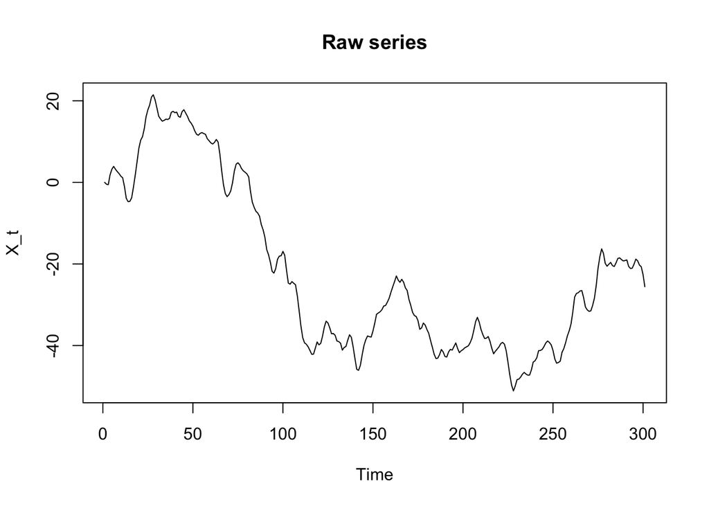

```r
x <- arima.sim(model = list(order = c(1, 1, 1), ar = 0.6, ma = 0.5), n = 300)
plot.ts(x, main = "Raw series", ylab = "X_t")
```

What the commands do:

- `order = c(1, 1, 1)` makes the first differences follow an ARMA(1,1).
- `ar = 0.6` gives persistence in those differences.
- `ma = 0.5` adds the previous shock with coefficient 0.5, corresponding to $\theta = -0.5$ in the notes.

Questions:

- Does the raw series look stationary?
- What feature suggests differencing?

## 2. Identification

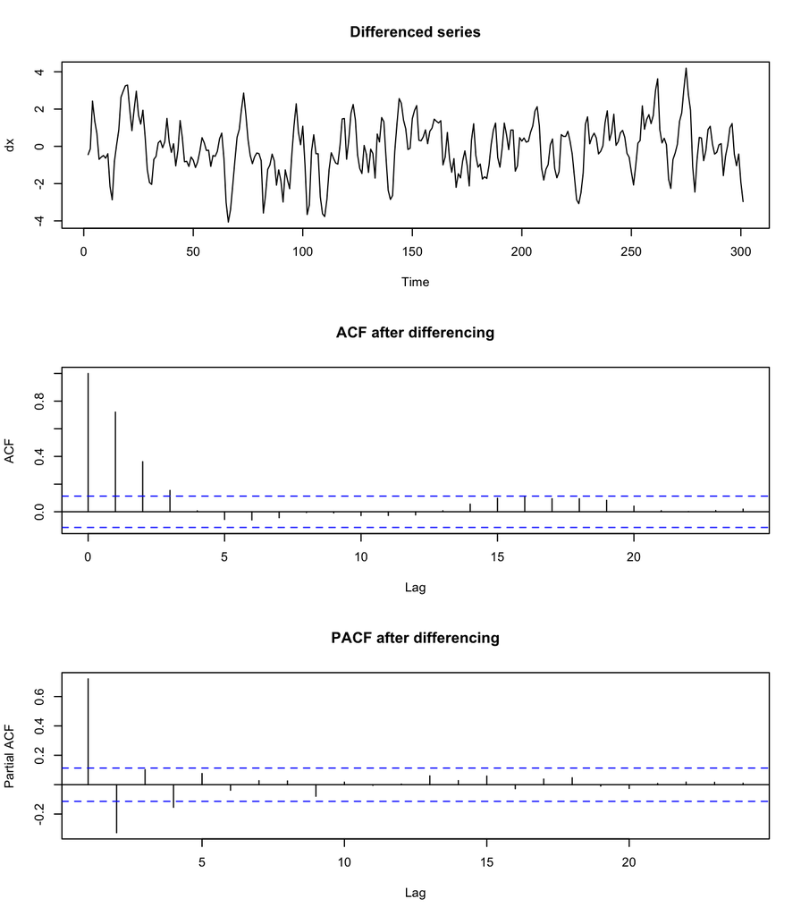

```r
dx <- diff(x)
par(mfrow = c(3, 1))
plot.ts(dx, main = "Differenced series")
acf(dx, main = "ACF after differencing")
pacf(dx, main = "PACF after differencing")
```

```r
par(mfrow = c(1, 1))
```

Augmented Dickey–Fuller test (notes, Section 2.2): $H_0$ is a unit root.

```r
tseries::adf.test(x)
```

```
##
##  Augmented Dickey-Fuller Test
##
## data:  x
## Dickey-Fuller = -1.2297, Lag order = 6, p-value = 0.9004
## alternative hypothesis: stationary
```

```r
tseries::adf.test(dx)
```

```
##
##  Augmented Dickey-Fuller Test
##
## data:  dx
## Dickey-Fuller = -5.6487, Lag order = 6, p-value = 0.01
## alternative hypothesis: stationary
```

What the commands do:

- `diff(x)` constructs the candidate stationary series.
- The ACF and PACF suggest orders for this differenced series, not the raw series.
- `tseries::adf.test()` runs the ADF test from the `tseries` package. A small p-value is evidence against the unit-root null for that test specification. A large p-value does not prove a unit root, and rejecting a unit root does not establish every condition for stationarity.

If needed, install the package once in the R console with `install.packages("tseries")` before running this demo.

Questions:

- Which value of $d$ do the plots and the ADF tests suggest?
- Does the ACF/PACF suggest AR, MA, or mixed ARMA behaviour?

## 3. ACF/PACF Pattern Reading

Before you estimate a model, practise reading simple patterns.

```r
# Values at lags 1-4. Checks: PACF(1) = ACF(1); an MA(1) has |rho_1| <= 1/2.
patterns <- data.frame(
  pattern = c("A", "B", "C", "D"),
  acf_lags_1_to_4 = c(
    "0.80, 0.64, 0.51, 0.41",
    "0.44, 0.00, 0.00, 0.00",
    "0.73, 0.44, 0.26, 0.16",
    "0.95, 0.90, 0.86, 0.82"
  ),
  pacf_lags_1_to_4 = c(
    "0.80, 0.00, 0.00, 0.00",
    "0.44, -0.24, 0.14, -0.08",
    "0.73, -0.21, 0.06, -0.02",
    "0.95, -0.03, 0.08, -0.02"
  )
)
patterns
```

```
##   pattern        acf_lags_1_to_4         pacf_lags_1_to_4
## 1       A 0.80, 0.64, 0.51, 0.41   0.80, 0.00, 0.00, 0.00
## 2       B 0.44, 0.00, 0.00, 0.00 0.44, -0.24, 0.14, -0.08
## 3       C 0.73, 0.44, 0.26, 0.16 0.73, -0.21, 0.06, -0.02
## 4       D 0.95, 0.90, 0.86, 0.82 0.95, -0.03, 0.08, -0.02
```

Questions:

- Which pattern has ACF tailing and PACF cutting off?
- Which pattern has ACF cutting off and PACF tailing?
- Which pattern looks nonstationary?
- Why should these be treated as candidate models, not final answers?

The table mixes theoretical patterns (A–C) with an illustrative sample pattern (D). In particular, a large first autocorrelation and slow decay do not distinguish a random walk from every highly persistent stationary series. Use the series plot and the differencing checks too.

Check your answers once you have tried. A-C are theoretical values from `ARMAacf()`; D is a typical sample ACF/PACF of a random walk.

```r
patterns$first_candidate <- c("AR(1), phi = 0.8",
                              "MA(1), theta = -0.6 (R: ma = 0.6)",
                              "ARMA(1,1), phi = 0.6, theta = -0.3 (R: ma = 0.3)",
                              "difference first (random walk)")
patterns[, c("pattern", "first_candidate")]
```

```
##   pattern                                  first_candidate
## 1       A                                 AR(1), phi = 0.8
## 2       B                MA(1), theta = -0.6 (R: ma = 0.6)
## 3       C ARMA(1,1), phi = 0.6, theta = -0.3 (R: ma = 0.3)
## 4       D                   difference first (random walk)
```

```r
round(ARMAacf(ma = 0.6, lag.max = 4, pacf = TRUE), 2)  # check row B
```

```
## [1]  0.44 -0.24  0.14 -0.08
```

Simulate the common clean patterns.

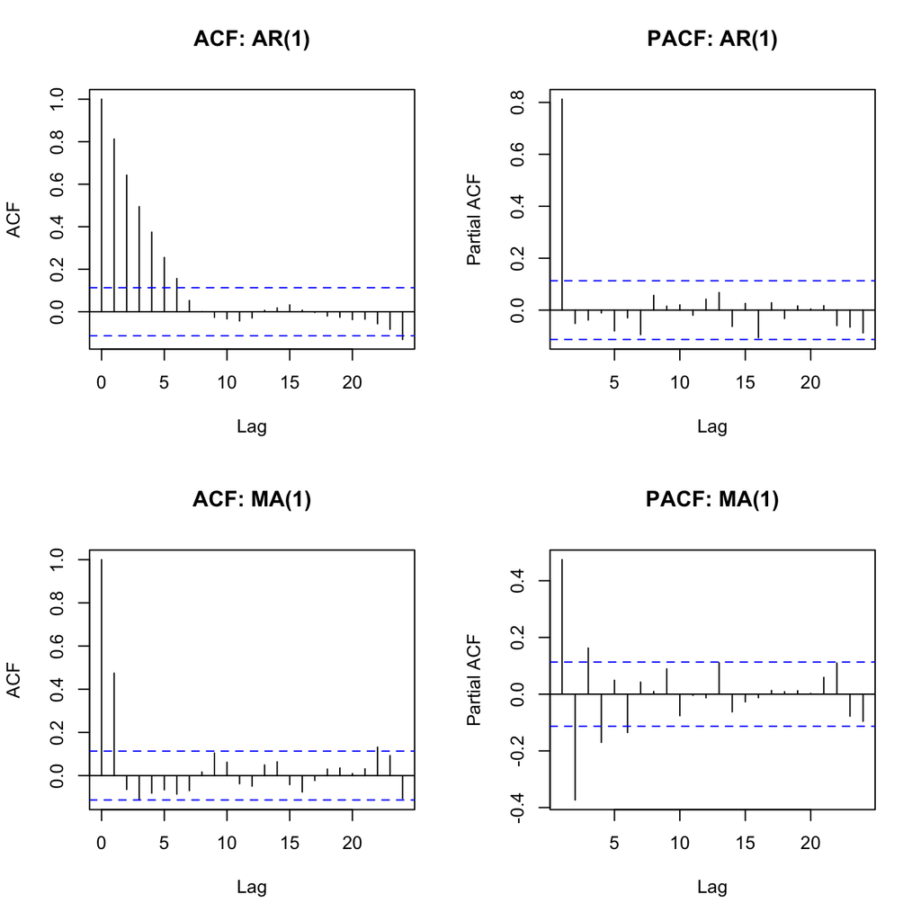

```r
set.seed(7)
ar1 <- arima.sim(model = list(ar = 0.8), n = 300)
ma1 <- arima.sim(model = list(ma = 0.8), n = 300)  # theta = -0.8

par(mfrow = c(2, 2))
acf(ar1, main = "ACF: AR(1)")
pacf(ar1, main = "PACF: AR(1)")
acf(ma1, main = "ACF: MA(1)")
pacf(ma1, main = "PACF: MA(1)")
```

```r
par(mfrow = c(1, 1))
```

Try it yourself:

- Change both sample sizes from `300` to `60`. Are the cut-offs as clear?
- Repeat with another seed. Does an isolated spike beyond the expected cut-off justify a higher order on its own?

## 4. Estimate Candidate Models

```r
fit_111 <- arima(x, order = c(1, 1, 1))
fit_011 <- arima(x, order = c(0, 1, 1))
fit_110 <- arima(x, order = c(1, 1, 0))

fit_111
```

```
##
## Call:
## arima(x = x, order = c(1, 1, 1))
##
## Coefficients:
##          ar1     ma1
##       0.5087  0.5355
## s.e.  0.0617  0.0620
##
## sigma^2 estimated as 0.8605:  log likelihood = -403.71,  aic = 813.41
```

```r
AIC(fit_111, fit_011, fit_110)
```

```
##         df      AIC
## fit_111  3 813.4107
## fit_011  2 864.6126
## fit_110  2 856.3489
```

```r
BIC(fit_111, fit_011, fit_110)
```

```
##         df      BIC
## fit_111  3 824.5221
## fit_011  2 872.0202
## fit_110  2 863.7565
```

What the commands do:

- Every fit uses the same raw observations and the same differencing order.
- The candidates differ only in whether they include AR and MA terms.
- AIC and BIC trade off fit and complexity. Inspect the residuals of the preferred candidate before forecasting.

Questions:

- Which model would you choose by AIC?
- Which model would you choose by BIC?
- R’s `ma1` is $-\hat\theta$: what are $\hat\phi$ and $\hat\theta$, and how close are they to the true values $0.6$ and $-0.5$?

## 5. Diagnose Residuals

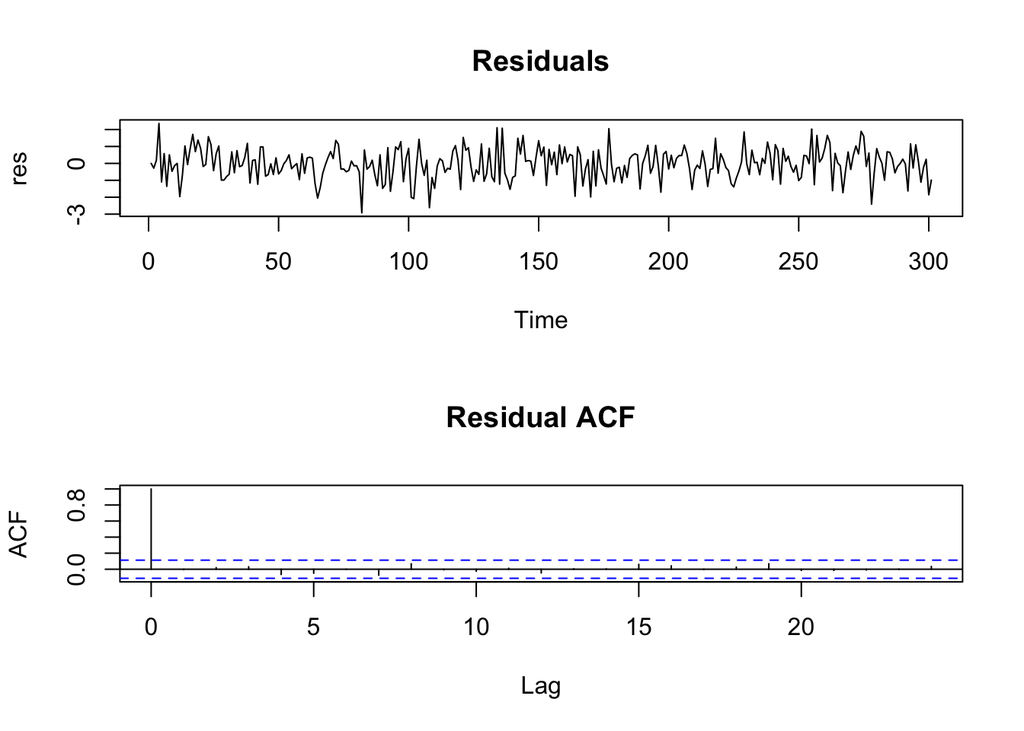

```r
res <- residuals(fit_111)
par(mfrow = c(2, 1))
plot.ts(res, main = "Residuals")
acf(res, main = "Residual ACF")
```

```r
par(mfrow = c(1, 1))
Box.test(res, lag = 20, type = "Ljung-Box", fitdf = 2)  # fitdf = p + q
```

```
##
##  Box-Ljung test
##
## data:  res
## X-squared = 10.205, df = 18, p-value = 0.925
```

```r
# AR and MA roots: R's MA polynomial is 1 + ma1 z
Mod(polyroot(c(1, -coef(fit_111)["ar1"])))
```

```
## [1] 1.965749
```

```r
Mod(polyroot(c(1, coef(fit_111)["ma1"])))
```

```
## [1] 1.867562
```

Questions:

- Do the residuals behave like white noise?
- Is the fitted model stationary and invertible?

For this integrated model, stationarity refers to the ARMA model for the first differences. The level series still has its differencing root at 1. The two root checks above concern the fitted AR and MA factors only.

### Compare a Simpler Candidate’s Residuals

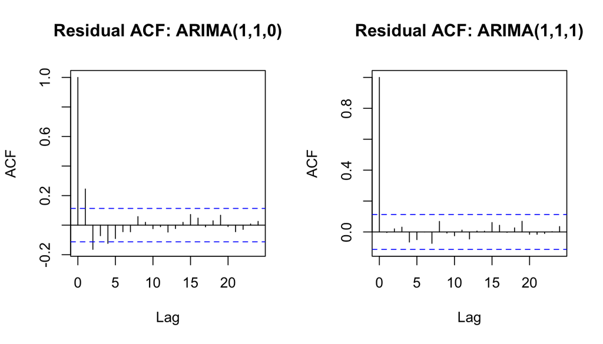

```r
par(mfrow = c(1, 2))
acf(residuals(fit_110), main = "Residual ACF: ARIMA(1,1,0)")
acf(residuals(fit_111), main = "Residual ACF: ARIMA(1,1,1)")
```

```r
par(mfrow = c(1, 1))
data.frame(
  model = c("ARIMA(1,1,0)", "ARIMA(1,1,1)"),
  ljung_box_p = c(
    Box.test(residuals(fit_110), lag = 20,
             type = "Ljung-Box", fitdf = 1)$p.value,
    Box.test(residuals(fit_111), lag = 20,
             type = "Ljung-Box", fitdf = 2)$p.value
  )
)
```

```
##          model ljung_box_p
## 1 ARIMA(1,1,0) 0.001281566
## 2 ARIMA(1,1,1) 0.924998419
```

Questions:

- Does the extra MA term remove a systematic residual pattern?
- Why does the degrees-of-freedom adjustment differ between these fits?
- If a chosen model fails the residual checks, which identification plot would you revisit before changing the order?

## 6. Forecast

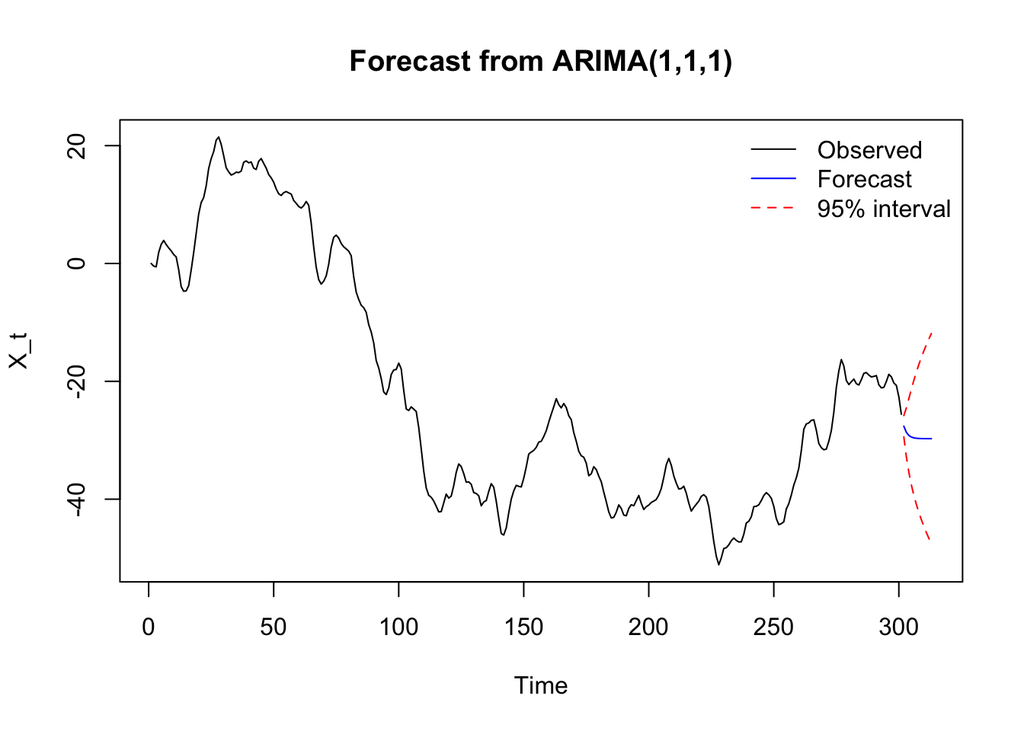

```r
pred <- predict(fit_111, n.ahead = 12)
lower <- pred$pred - 1.96 * pred$se   # approximate 95% prediction interval
upper <- pred$pred + 1.96 * pred$se
ts.plot(x, pred$pred, lower, upper, col = c("black", "blue", "red", "red"),
        lty = c(1, 1, 2, 2), main = "Forecast from ARIMA(1,1,1)", ylab = "X_t")
legend("topright", legend = c("Observed", "Forecast", "95% interval"),
       col = c("black", "blue", "red"), lty = c(1, 1, 2), bty = "n")
```

Questions:

- Why do the intervals keep widening with the horizon?

What the commands do:

- `predict(..., n.ahead = 12)` returns forecasts and their standard errors.
- The lower and upper limits are approximate 95% prediction limits using normal errors and the fitted parameters. They omit parameter uncertainty.
- `ts.plot()` puts observations and forecasts on the same time axis.

### Inspect the Last Observations and the Forecasts

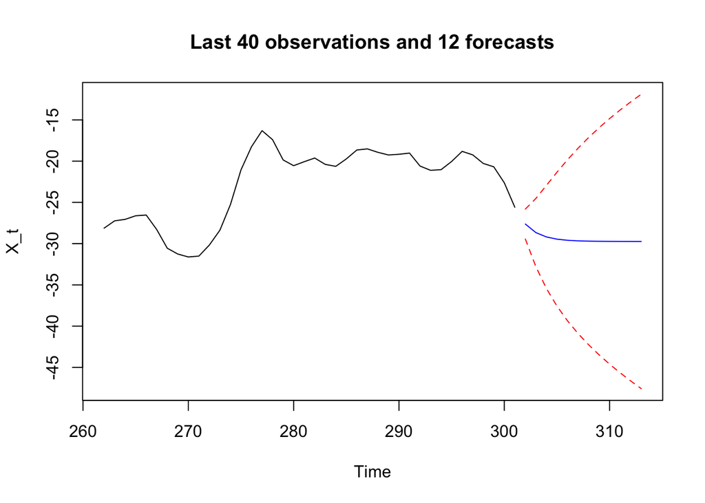

```r
ts.plot(window(x, start = tail(time(x), 40)[1]), pred$pred, lower, upper,
        col = c("black", "blue", "red", "red"), lty = c(1, 1, 2, 2),
        main = "Last 40 observations and 12 forecasts", ylab = "X_t")
```

```r
data.frame(
  horizon = 1:12,
  forecast = round(as.numeric(pred$pred), 3),
  lower = round(as.numeric(lower), 3),
  upper = round(as.numeric(upper), 3)
)
```

```
##    horizon forecast   lower   upper
## 1        1  -27.625 -29.443 -25.807
## 2        2  -28.661 -32.798 -24.523
## 3        3  -29.188 -35.436 -22.939
## 4        4  -29.456 -37.568 -21.344
## 5        5  -29.592 -39.351 -19.834
## 6        6  -29.662 -40.888 -18.435
## 7        7  -29.697 -42.250 -17.144
## 8        8  -29.715 -43.480 -15.950
## 9        9  -29.724 -44.609 -14.839
## 10      10  -29.729 -45.659 -13.799
## 11      11  -29.731 -46.643 -12.820
## 12      12  -29.732 -47.572 -11.892
```

Try it yourself:

- Change the horizon to `24` and rerun the two forecast chunks, changing `horizon = 1:12` to `horizon = 1:24` in the table.
- Compare the interval widths with those of the stationary AR(2) in Chapter 4.
- Explain why a fitted mean-reverting difference need not make the level forecasts return to a fixed long-run mean.